# Employment

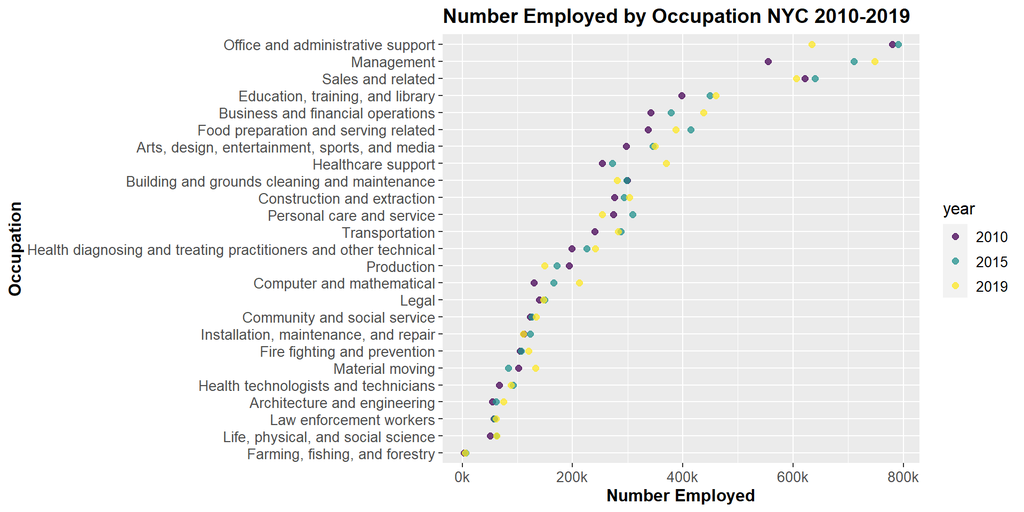

```r
ggplot(TrimmedAggregateYearlyData) +
geom_point(aes(YearlyNumEmp, reorder(Occupations,YearlyNumEmp), color = year),size = 2, alpha = 0.75) + ylab('Occupation') + xlab('Number Employed') + ggtitle('Number Employed by Occupation NYC 2010-2019') + scale_x_continuous(labels = ks) +
  mytheme
```

**Observations on Number Employed by Occupation NYC through 2010-2019:**

The most striking observations from this Cleveland dot plot are where there are clear trends over the decade, that coincide with intuition about the general trend of a sector. Some of the most striking trends are:

4.) Health care support occupations growing at a stagnant rate from 2010 to 2015, but then growing rapidly from 2015 to 2019.

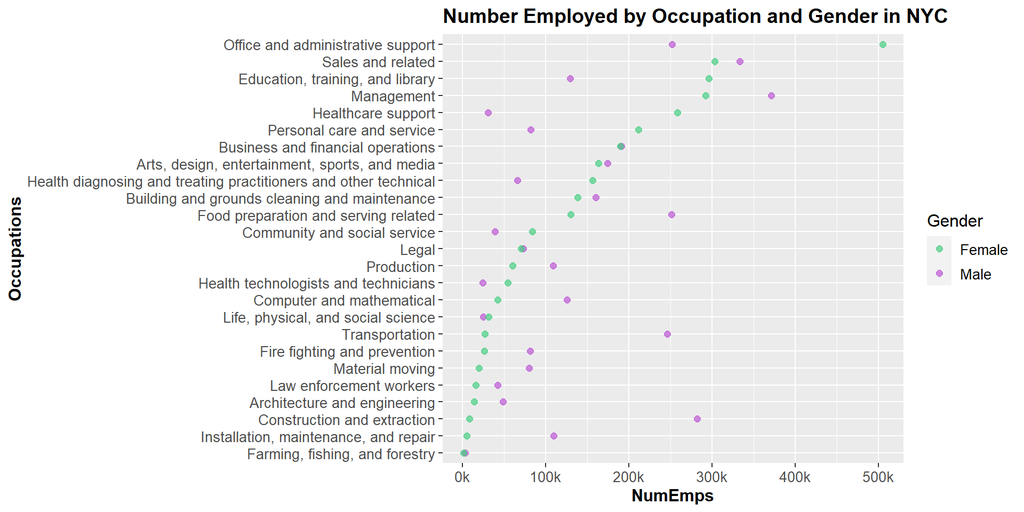

```r
ggplot(GenderData, aes(MeanNumEmpbyGender,fct_reorder2(Occupations,Gender=='Female',MeanNumEmpbyGender, .desc=FALSE), color = Gender)) +
  geom_point(size = 2, alpha = 0.7) +
  ylab('Occupations') + xlab('NumEmps') + ggtitle('Number Employed by Occupation and Gender in NYC') +
scale_x_continuous(labels = ks) + scale_color_manual(values=c('seagreen3','mediumorchid')) +
  mytheme
```

A broad takeaway from studying this plot is that generally men tend to dominate the majority of professions, with 17 occupations being majority male, and only 8 occupations being majority female.  
The occupations in which females account for the vast majority of employees are Office and administrative support, education, training, and library, healthcare support, and personal care and service.  
The occupations in which males account for the vast majority of employees are construction and extraction, transportation, and installation, maintenance and repair.

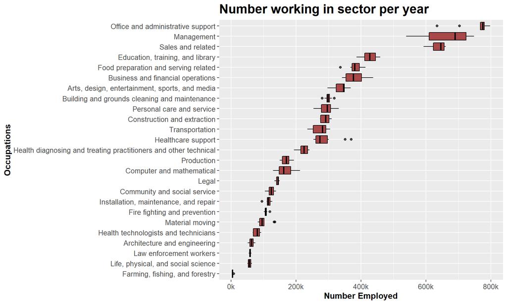

```r
ggplot(YearlyNumEmps) +
  geom_boxplot(aes(x = YearlyNumEmp, y = reorder(x = Occupations,YearlyNumEmp, FUN = median)),
               color = "black", fill = "dark red", alpha = 0.7) +
  ggtitle("Number working in sector per year") +
  xlab("Number Employed") + ylab("Occupations") +
  mytheme1 +
  scale_x_continuous(labels = ks)
```

**Observations from Boxplot of number working in sector per year:**

Occupations that seem prone to dramatic fluctuation over time:

1.) Management occupations

2.) Office and administrative support occupations

3.) Health care support occupations

4.) Computer and Mathematical occupations

Occupations where the number of employees has fluctuated very little:

1.)Law enforcement

2.)Fire fighting

3.)Building and grounds keeping occupations

4.)Legal occupations

Something to be noted when reading this plot is that the number of people working in any particular occupation may change the viewers perception as to what constitutes more variation. To address this, a second plot has been created in which the box plots are normalized by dividing the number employed in each year by the mean across this sector. While the variation in total number employed won’t be apparent, the relative degrees of fluctuation will become more apparent.

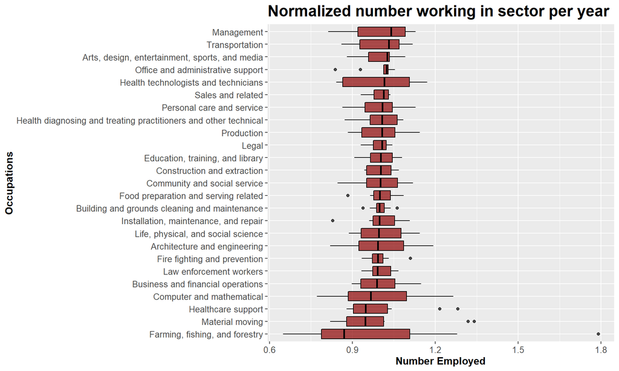

```r
ggplot(YearlyNumEmps) +
  geom_boxplot(aes(x = Normalized, y = reorder(x = Occupations,Normalized, FUN = median)),
               color = "black", fill = "dark red", alpha = 0.7) +
  ggtitle("Normalized number working in sector per year") +
  xlab("Number Employed") + ylab("Occupations") +
  mytheme1
```

**Observations from number working in sector per year:**

In this plot, the total values of employees working in each field in each year are normalized by their averages. In doing this, changes in employment in a sector that on an absolute scale would be small, may be more pronounced as a function of variation relative to it’s own size.

In this plot, the average quantity across all years is normalized to one for illustrative purposes, which allows for new interpretations and findings:

This indicates that the number of people working in law enforcement and firefighting is very stable, and this would make sense because a steady supply of people in these roles is necessary. With regards to the other occupations, it also makes sense that relatively unpopulated occupations would be more prone to greater variation as a percent of itself, since relatively few can leave or join, and a big impact can be had.

3.) As a percent of the number of employees working in each sector, the following were most prone to large shifts in number employed:

- Farming, fishing and forestry
- Material moving occupations
- Computer and mathematical occupations
- Health technologists and technicians
- Healthcare support occupations

By contrast, these professions were the most stable:

- Legal occupations
- Sales occupations
- Law enforcement workers
- Fire fighters
- Construction and extraction occupations

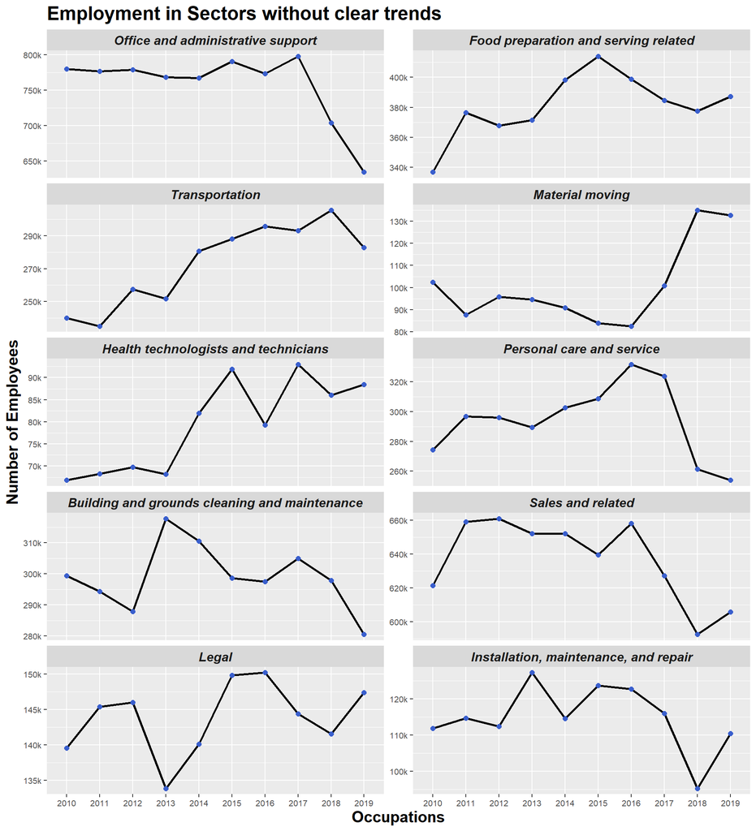

```r
ggplot(NotMonotonous,aes(year,YearlyNumEmp,group = Occupations)) +
  geom_line(size = 1,color = "black") +
  geom_point(color = "royalblue3", size = 2) +
  facet_wrap(~Occupations,ncol=2,scales = "free_y") +
  scale_y_continuous(labels = ks) +
    theme(axis.text=element_text(size=8),
      axis.title=element_text(size=15,face="bold"),
        strip.text.x = element_text(
        size = 12, face = "bold.italic"
        ),
      strip.text.y = element_text(
        size = 12, color = "red", face = "bold.italic"
        ),
      plot.title = element_text(size = 18, face = "bold"))+
  ylab('Number of Employees') + xlab('Occupations') + ggtitle('Employment in Sectors without clear trends')
```

**Observations from sectors without clear employment trends:**

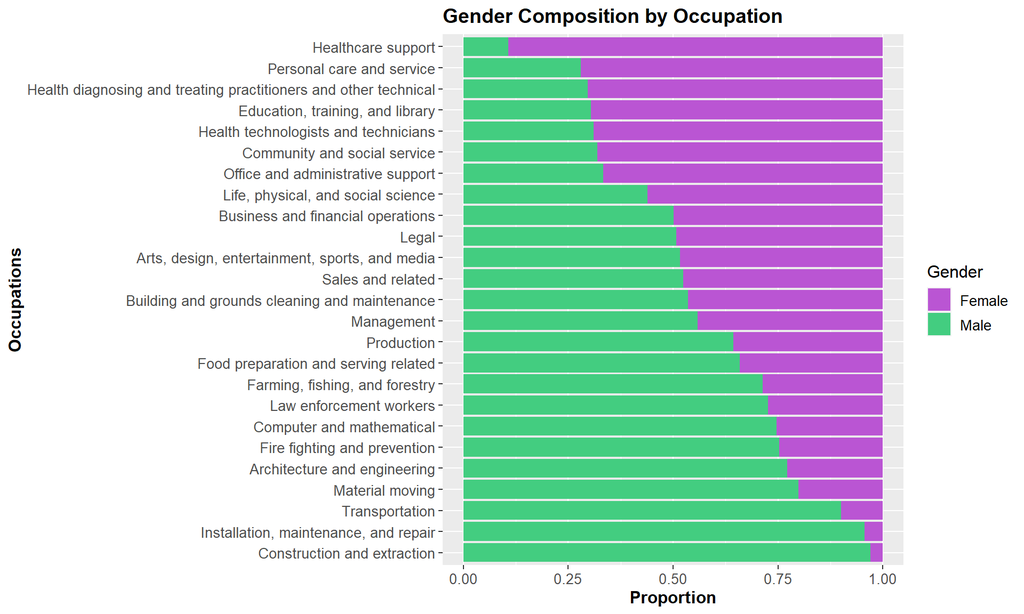

```r
ggplot(GenderData.tidy,aes(x = fct_reorder2(Occupations,Gender == "Female",prop,.desc=FALSE), y=prop,fill=Gender,group=Gender)) +
  geom_bar(position='fill', stat='identity')+
  coord_flip()+
  ylab('Proportion') + xlab('Occupations') + ggtitle('Gender Composition by Occupation')+
  scale_fill_manual(values=c('mediumorchid','seagreen3')) +
  mytheme
```

**Observations from gender composition by occupation**

From this plot, we can list the top ten occupations with high percentages of male and the top 10 occupations with high percentages of female.

## Top 10 occupations for males

1. Construction and extraction occupations
2. Installation, maintenance and repair occupations
3. Transportation occupations
4. Material moving occupations
5. Architecture and engineering occupations
6. Fire fighting and prevention, and other protective service workers including supervisors
7. Computer and mathematical occupations
8. Law enforcement workers including supervisors
9. Farming, fishing and forestry occupations
10. Food preparation and serving related occupations

## Top 10 occupations for females

1. Healthcare support occupations
2. Personal care and service occupations
3. Health, design and treating practitioners and other technical occupations
4. Education, training and library occupations
5. Health technologists and technicians
6. Community and social service occupations
7. Office and administrative support occupations
8. Life, physical, and social service occupations
9. Business and financial operations occupations
10. Legal occupations

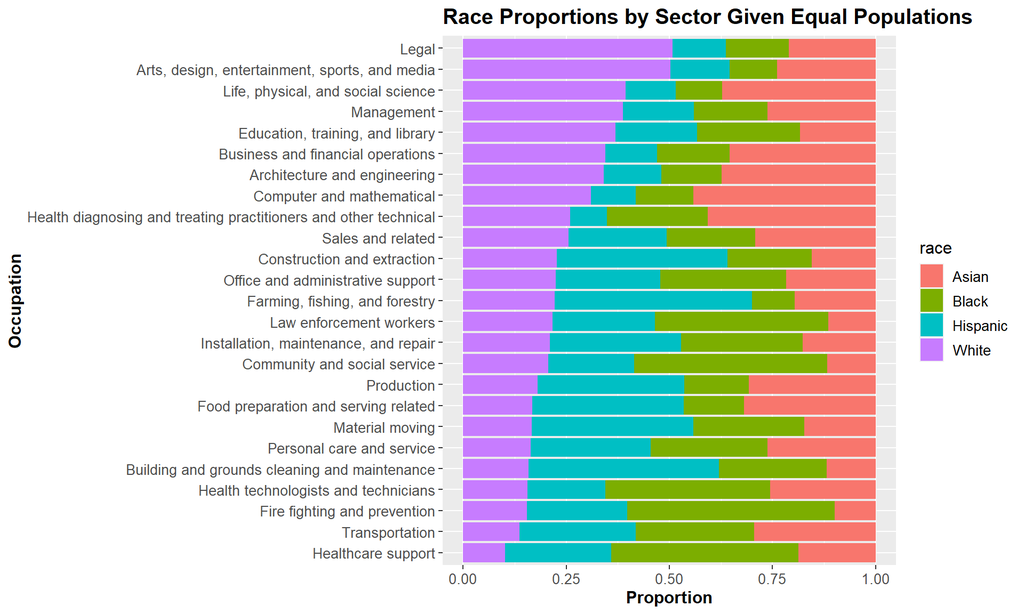

```r
PropsOfPropsRace$Occupation <- as.factor(PropsOfPropsRace$Occupation)
PropsOfPropsRace$Occupation <- fct_reorder(PropsOfPropsRace$Occupation, PropsOfPropsRace$White, .desc = FALSE)
PropsOfPropsRaceTidy <- pivot_longer(PropsOfPropsRace, cols = c('White','Asian','Hispanic','Black'), names_to = 'race', values_to = 'Proportion')
PropsOfPropsRaceTidy$Occupation <- as.factor(PropsOfPropsRaceTidy$Occupation)
ggplot(PropsOfPropsRaceTidy, aes(fill = race, y = Occupation, x = Proportion)) + geom_bar(position = 'stack',stat = 'identity') + ggtitle('Race Proportions by Sector Given Equal Populations') +
  mytheme2
```

**Observations from Relative Likelihood of Sector Employment by Race:**  
Note: This plot was formed by comparing the proportions of each race group working in each sector. If for a particular sector each group accounts for 0.25 in this plot, then each race group has the same percentage of its people working in that sector. This has the effect of displaying what the race demographics of a sector would look like assuming all races had the same population.  
1.) It seems that a typical white person is much more likely than persons of other races to work legal profession compared to other races. They are also quite likely compared to other races to engage in Management occupations, physical, life and social science occupations, and art, design, entertainment, sports and media occupations.

2.) It seems that a typical white person is much less likely than persons of other races to work in health care support occupations, transportation occupations, production occupations, personal care and service occupations, material moving operations, and building and grounds cleaning and maintenance occupations

3.) It seems that a typical Hispanic person is much more likely than person of other races to work in Farming, Fishing and forestry occupations. They are also quite likely compared to other races to engage in building and grounds cleaning and maintenance occupations, construction and extraction operations, and material moving operations.

4.) It seems that a typical Hispanic person is much less likely than persons of other races to work in health diagnosing and treating practitioners and other technical occupations, business and financial operations, computer and mathematical occupations, legal occupations, art, design, entertainment, sports, and media occupations, architecture and engineering occupations, and life, physical, and social science occupations.

5.) It seems that a typical Black person is much more likely than persons of other races to work in fire fighting and prevention and other protective services including supervisors, law enforcement workers including supervisors, healthcare and support occupations, and community and social service occupations.

6.) It seems that a typical Black person is much less likely than persons of other races to work in architecture and engineering occupations, art, design, entertainment, sports and media occupations, farming, fishing, and forestry occupations, food preparation and serving occupations, life, physical and social science occupations, and legal occupations.

7.) It seems that a typical Asian person is much more likely than persons of other races to work in computer and mathematical operations, architecture and engineering operations, business and financial operations, health diagnosing and treating practitioners and other technical occupations.

8.) It seems that a typical Asian person is much less likely than persons of other races to work in Law enforcement occupations, fire fighting and prevention occupations, community and social service occupations, and building and grounds cleaning and maintenance occupations.\

```r
parcoords(YearBoroughData.wide,
          rownames = F,
          brushMode = "1D-axes",
          reorderable = T,
          queue = T,
          color = list(
            colorBy = "County",
            colorScale = "scaleOrdinal",
            colorScheme = "schemeCategory10"
          ),
          withD3 = TRUE)
```

[interactive chart not shown]

**Plot abbreviations key:**

MBSC: Management, business, science, and arts  
NRCM: Natural resources, construction, maintenance  
PTMM: Production, transportation, material moving

Note: Each line represents one year. The numbers on the axis represent the proportion of the working population of that county working in each of the categories for that year. The numbers across each sector for each year sum to one.

**Observations from sector groups employment across counties:**  
Observing this plot is that certain counties stand out in terms of how many of their people work in certain areas:  
New York has great representation in Management, business, science, and arts with roughly 60% of its population routinely working in those fields across 2010-2019, which is at roughly 15% higher than for any other county.  
Bronx County has great representation in service occupations, with roughly 35% of its population working routinely in this sector, which is at least 10% higher than for any other county.  
Richmond County and Queens County seem to have good representation in natural resources, construction, and maintenance occupations.  
New York, perhaps because of the high representation in the management, business, science, and arts cluster has clearly the lowest representation in service, natural resources, construction and maintenance, and production, transportation, management and material moving. New York also has the lowest representation in several years in Sales and Office occupations.  
Of all the counties, Queens county, Kings county, and Richmond county seem to track each other most, and have the most similar levels of representation across the sector clusters.  
Of all the counties, New York county and Bronx county seem to be the most different. Across almost each sector, low values for one almost certainly means that high values will appear for the other.